# exam L3 2022 solution

# Consignes générales

**Téléchargez le dossier Exam_terminal dans Moodle qui contient:**

**- Un fichier `exam.html` qui contient l’énoncé de l’exam (une copie de cet énoncé)**

**- Un fichier `exam.R` qui contient le script R dans lequel vous allez mettre vos scripts et réponses aux questions**

**- Un dossier `data` qui contient les données**

**Ouvrez `exam.R` et sauvez le dans le même dossier sous le nom `Exam_numéro_étudiant.R` en remplaçant `numéro_étudiant` par votre propre numéro étudiant.**

**Pour chaque question, dans le fichier `Exam_numéro_étudiant.R`:**

**- Commentez le code (en utilisant #) pour expliquer ce que vous allez faire et pourquoi vous utilisez telle ou telle fonction**

**- Utilisez des commandes appropriées pour répondre à la question**

**- Et finalement répondez (en commentant avec un #) à la question grâce au résultat des commandes**

**L’exam fini à 11h15. Quand vous avez fini, déposez dans l’espace de dépôt Moodle votre script `Exam_numéro_etudiant.R`, ainsi que les screenshots de ePlant.Avant de sortir de la salle, vérifiez auprès de Sandra Cortijo que vos fichiers sont bien dans l’espace de dépôt Moodle.**

**N’oubliez pas d’enregistrer régulièrement `Exam_numéro_étudiant.R` pendant l’exam.**

# Description des données

Pour l’examen, vous allez analyser des données extraites de [Wang et al., 2022](https://www.nature.com/articles/s41477-022-01236-5).

Il s’agit de données issues d’expériences pour mesurer l’impact de la mutation et de la sur-expression du gène *KIN10* chez *Arabidopsis thaliana*.

Pour cela l’aire des feuilles d’*Arabidopsis thaliana* a été mesurée et est indiquée en cm<sup>2</sup> (colonne `leaf_area_cm2`) chez trois `genotype`: `Col-0`, le mutant `kin-10` et le sur-expresseur `p35S:KIN10`. L’aire des feuilles a été mesurée chez des plantes ayant poussé avec deux types d’intensité lumineuse (colonne `light_intensity`) et qui ont subit un traitement (colonne `treatment`).

L’objectif de cet examen est de définir si la mutation ou la sur-expression du gène *KIN10* ont un impact phénotypique et si cet impact est influencé par l’environnement.

# Préparation de l’environnement de travail

## Question 0 (1 point)

> **Chargez les librairies dont vous aurez besoin.**

```r
library(tidyverse)
library(ggpubr)
```

> **Définissez le working directory de R pour être dans le dossier de l’exam.**

```r
getwd() #regarder où est le répertoire de travail
setwd("chemin vers le dossier de l'exam") #changer le répertoire de travail
```

> **Chargez le fichier *Exam_L3_bioinfo.txt* (qui est dans le dossier */data*), qui contient les données de phénotypage pour le mutant et le sur-expresseur de *KIN10*, dans R et sauvez le dans un objet.**

> *Aide: Utilisez la fonction appropriée pour le type de données (dans ce cas, des colonnes séparées par une tabulation)*

```r
kin10 <- read_tsv("Exam_L3_bioinfo.txt")
kin10
```

```
## # A tibble: 444 × 4
##    genotype light_intensity treatment leaf_area_cm2
##    <chr>              <dbl> <chr>             <dbl>
##  1 Col-0                 80 KCl               0.827
##  2 Col-0                 80 KCl               0.697
##  3 Col-0                 80 KCl               0.789
##  4 Col-0                 80 KCl               0.515
##  5 Col-0                 80 KCl               0.598
##  6 Col-0                 80 KCl               0.594
##  7 Col-0                 80 KCl               0.634
##  8 Col-0                 80 KCl               0.503
##  9 Col-0                 80 KCl               0.443
## 10 Col-0                 80 KCl               0.614
## # … with 434 more rows
```

> Pensez à inspecter ce que retourne cette commande dans la console pour avoir un tout premier aperçu des données et vérifier qu’elles sont encodées correctement.

```r
# Pour inspecter les données, utilisez la fonction
# View(kin10)
```

# Vérification des données

> Avant d’analyser les données, la première étape consiste à vérifier que le tableau importé dans *R* contient bien les données attendues.

## Question 1 (1.5 point)

> **Combien y a t’il de lignes et de colonnes?**

```r
dim(kin10)
```

```
## [1] 444   4
```

## Question 2 (2 point)

> **Combien y-a-t-il de traitements effectués? Donnez la liste des traitements**

```r
distinct(kin10, treatment)
```

```
## # A tibble: 3 × 1
##   treatment
##   <chr>
## 1 KCl
## 2 NH4+
## 3 NO3-
```

Il y a 3 traitements effectués: KCl, NH4+ et NO3-

# Etude de l’impact phénotypique de la mutation et de le sur-expresseur de *KIN10*

## Question 3 (6 points)

> **Faites une figure représentant la distribution de la taille des feuilles (en mm<sup>2</sup>) pour chaque génotype, avec l’intérieur des violin plots colorés en fonction du traitement effectué, et ce uniquement pour les plantes qui ont poussé avec une intensité lumineuse de 80. Ajoutez le résultat d’un test statistique comparant les moyennes des différents groupes.**

> *Aide : Pour cela, filtrez les données pour garder seulement l’intensité lumineuse de 80. Créez une nouvelle colonne contenant l’aire de la feuille en mm<sup>2</sup> à partir de celle existante qui contient l’aire en de la feuille en cm<sup>2</sup>. Puis, réalisez des violin plot de l’aire de la feuille en mm pour les différent génotypes que vous colorez en fonction du traitement. Pour finir ajoutez au graphique un test de comparaison de moyennes.*

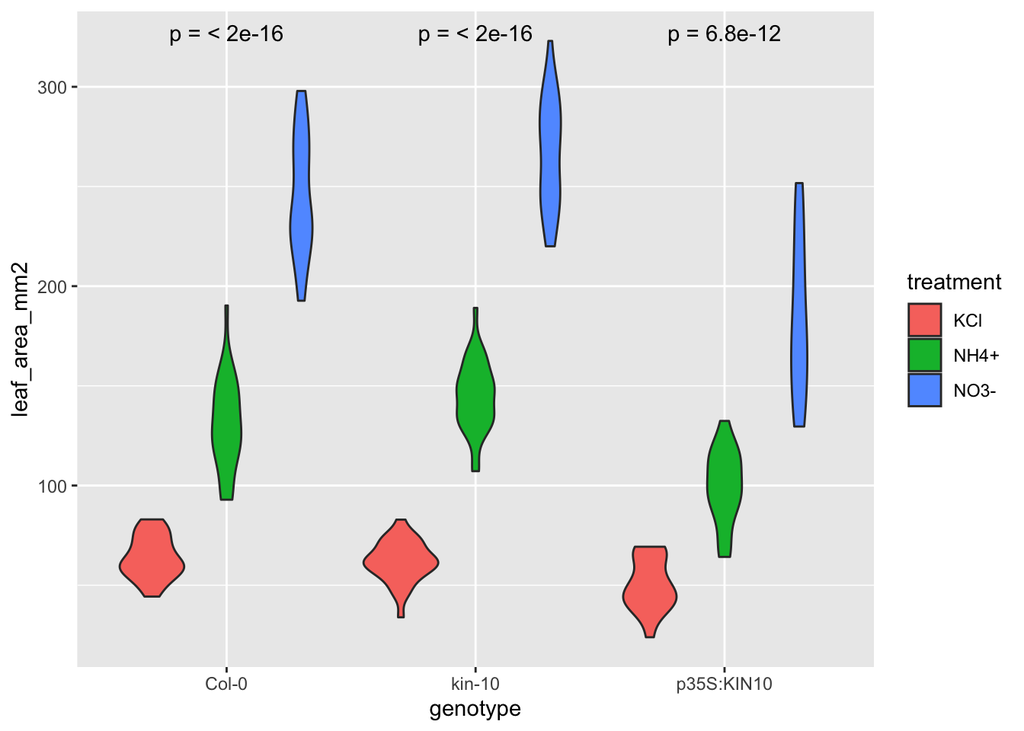

```r
filter(kin10, light_intensity==80) %>%
  mutate(leaf_area_mm2=leaf_area_cm2*100) %>%
  ggplot(aes(x=genotype, y=leaf_area_mm2, fill=treatment )) +
  geom_violin() +
  stat_compare_means(label="p.format")
```

> **Formulez une interprétation de ce que nous apprend cette figure quant à l’influence du traitement effectué sur la taille des feuilles. Est-ce que tous les génotypes répondent aux traitements?**

L’aire des feuilles est augmentée par les traitements NH4+ et NO3- par rapport au trairement KCl et ce pour tous les génotypes.

## Question 4 (5.5 points: 2pt pour graph, 2.5pt pour group_by/summarise, 1pt interpretation )

> **Faites une figure représentant la distribution de la taille des feuilles (en mm<sup>2</sup>) pour chaque traitement, avec l’intérieur des violin plots colorés en fonction du génotype, et ce uniquement pour les génotypes `Col-0` et `kin-10`. Créez deux facets en fonction de l’intensité lumineuse utilisée. Ajoutez le résultat d’un test statistique comparant les moyennes des différents groupes.**

> **Lisez bien la consigne car ce graphique est différent de celui de la question précédente.**

> *Aide : Pour cela, filtrez les données pour enlever le génotype `p35S:KIN10`. Créez une nouvelle colonne contenant l’aire de la feuille en mm<sup>2</sup> à partir de celle existante qui contient l’aire en de la feuille en cm<sup>2</sup>. Puis, réalisez des violin plot de l’aire de la feuille en mm<sup>2</sup> pour les différent traitements que vous colorez en fonction du génotype, avec des facets en fonction de l’intensité lumineuse. Pour finir ajoutez au graphique un test de comparaison de moyennes.*

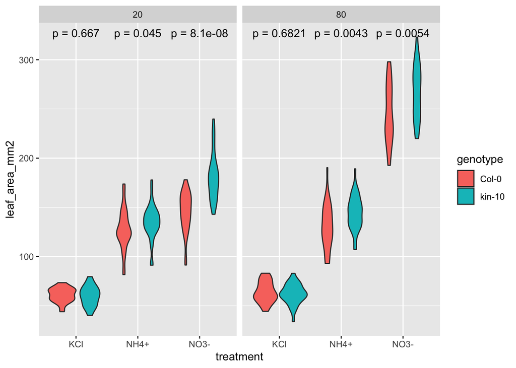

```r
filter(kin10, genotype!="p35S:KIN10") %>%
  mutate(leaf_area_mm2=leaf_area_cm2*100) %>%
  ggplot(aes(x=treatment, y=leaf_area_mm2, fill=genotype)) +
  geom_violin() +
  stat_compare_means(label="p.format") +
  facet_wrap(~light_intensity)
```

> **Pour confirmer le résultat de ce graphique, calculez et affichez dans la console la moyenne de l’aire de la feuille (en mm<sup>2</sup>) pour l’intensité lumineuse et chaque traitement en fonction du génotype. Effectuez ceci uniquement sur les génotypes `Col-0` et `kin-10`.**

```r
filter(kin10,  genotype!="p35S:KIN10") %>%
  mutate(leaf_area_mm2=leaf_area_cm2*100) %>%
  group_by(light_intensity, treatment, genotype) %>%
  summarise(average_area_leaf_mm2=mean(leaf_area_mm2))
```

```
## # A tibble: 12 × 4
## # Groups:   light_intensity, treatment [6]
##    light_intensity treatment genotype average_area_leaf_mm2
##              <dbl> <chr>     <chr>                    <dbl>
##  1              20 KCl       Col-0                     60.9
##  2              20 KCl       kin-10                    59.8
##  3              20 NH4+      Col-0                    128.
##  4              20 NH4+      kin-10                   135.
##  5              20 NO3-      Col-0                    145.
##  6              20 NO3-      kin-10                   181.
##  7              80 KCl       Col-0                     63.8
##  8              80 KCl       kin-10                    61.8
##  9              80 NH4+      Col-0                    130.
## 10              80 NH4+      kin-10                   145.
## 11              80 NO3-      Col-0                    245.
## 12              80 NO3-      kin-10                   267.
```

> **Formulez une interprétation complète de ce que nous apprend cette figure et l’extraction des moyennes de l’aire des feuilles quant à l’effet du traitement effectué sur le génotype du mutant *kin-10*.** **Est-ce que l’effet de cette mutation est visible dans toutes les conditions?**

L’effet de la mutation *kin10* sur l’aire des feuilles n’est pas visible chez les plantes traitées au KCl. Par contre pour les plantes traitées avec du NH4+ et du NO3-, la mutation *kin10* est associées à une augmentation de l’aire des feuilles. Cet effet est plus important quand les plantes sont traitées avec du NO3-. Les résultats sont les mêmes peu importe l’intensité lumineuse analysée.

# Etude du gène *KIN10* en utilisant une base de donnée

## Question 5 (4.5 points: 1pt q1, 1.5pt q2 et 2pt q3)

Pour les questions suivantes, utilisez les outils proposés par l’ePlant de BAR. **Vos réponses devront s’accompagner de copies d’écran permettant de suivre vos analyses in silico. Pensez à indiquer dans votre réponse à chaque question le nom du fichier de cette copie d’écran à les déposer sur Moodle avec votre script.**

> **Quelle est la fonction du gène d’Arabidopsis At3g01090 (*KIN10*) ?**

*KIN10* est une kinase SNF1-related

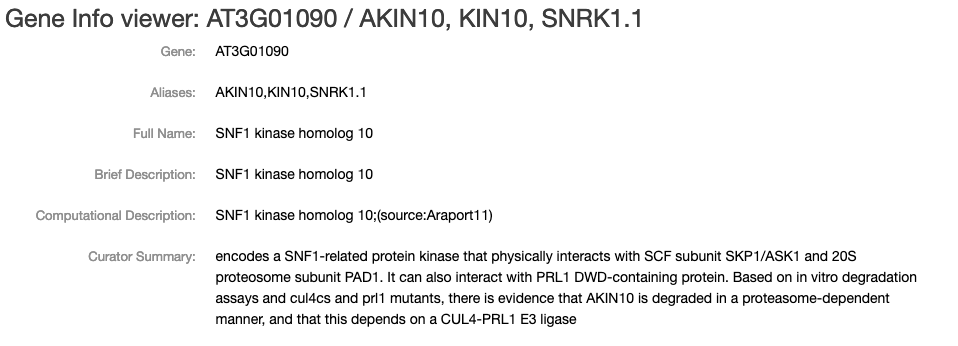

> **Quel est le gène le plus similaire à At3g01090 (*KIN10*) chez Arabidopsis ?**

Le gène le plus similaire à At3g01090 (*KIN10*) est At3g29160 (*KIN11*).

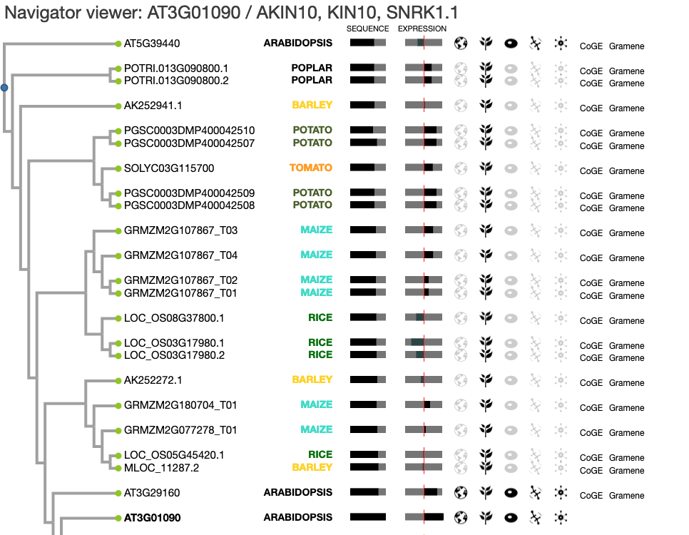

> **Est-ce que ces deux gènes répondent de la même manière à un traitement à l’azote (nitrogen)?**

*KIN10* montre une légère augmentation de l’expression en réponse à l’azote dans la lateral root cap, mais ne réponds pas dans les autres types cellulaires de la racine. *KIN11* ne réponds pas à l’azote. Ces deux gènes ont donc une réponse différente à l’azote dans la latéral root cap, mais se comportent de la même manière dans les autres types cellulaires.

Réponse à l’azote pour *KIN10*:

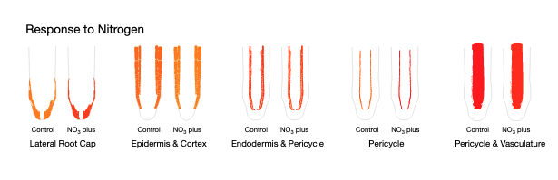

Réponse à l’azote pour *KIN11*:

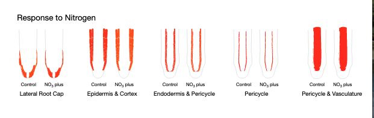

**Fin de l’exam. N’oubliez pas de vous relire, et de déposer votre script `Exam_numéro_etudiant.R`, ainsi que les screenshots de ePlant sur l’espace de dépôt Moodle. Avant de sortir de la salle, vérifiez auprès de Sandra Cortijo que le dépôt a bien été effectué.**